# Introdução à economia

Aula 21 - Desigualdade de renda e pobreza

Prof. Roberto de Freitas Neder

## Aula 21: roteiro

**Desigualdade de renda e pobreza** · Mankiw, capítulo 20 · UnB

- Medir desigualdade e pobreza
- Limites das medidas
- Critérios de justiça
- Políticas contra a pobreza
- Conclusão
- Exercícios de concursos públicos

Use as setas para trocar de slide. Nas páginas longas, role o conteúdo. As respostas das atividades ficam fechadas até o clique.

## 01 - Crescer e distribuir

O PIB por habitante pode crescer sem que todas as pessoas melhorem de vida. Nesta aula, examinaremos **como a renda se distribui**, quem permanece abaixo de um padrão mínimo e quais critérios orientam políticas de redistribuição.

O capítulo reúne três perguntas: como medir desigualdade, como discutir justiça distributiva e como desenhar políticas de combate à pobreza.

Separaremos afirmações empíricas de julgamentos de valor. A economia ajuda a examinar consequências, mas não escolhe sozinha o que uma sociedade considera justo.

**Base:** Mankiw, capítulo 20, *Income Inequality and Poverty*, pp. 401 a 422. PDF: pp. 430 a 451.

← Menu

## 02 - Desigualdade e pobreza

**Desigualdade** trata das diferenças de renda, patrimônio ou oportunidades entre pessoas e grupos. **Pobreza** trata da insuficiência de recursos para atender a um padrão definido.

Uma sociedade pode ter rendas muito próximas e, ainda assim, todas serem insuficientes. Outra pode reduzir a pobreza e continuar muito desigual.

Se todos ganham 10% a mais, uma medida relativa de desigualdade pode permanecer igual, enquanto pessoas ultrapassam uma linha de pobreza fixa em termos reais.

Antes de avaliar um indicador, identifique sua unidade, sua população e o conceito de renda utilizado.

← Menu

## 03 - Quintis e participação na renda

Ordene famílias por renda e divida-as em cinco grupos de igual tamanho: os **quintis**. Cada grupo representa 20% das famílias, mas não necessariamente 20% da renda.

| Quintil, do mais pobre ao mais rico | Participação hipotética |
| --- | --- |
| Primeiro | 5% |
| Segundo | 10% |
| Terceiro | 15% |
| Quarto | 25% |
| Quinto | 45% |

O quinto recebe nove vezes a renda total do primeiro. Esses grupos descrevem posições na distribuição, não necessariamente as mesmas famílias ao longo dos anos.

← Menu

## 04 - Curva de Lorenz

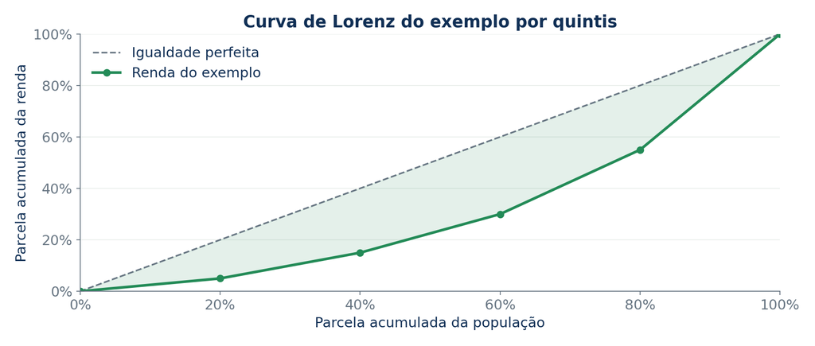

Curva de Lorenz de uma distribuição hipotética com participações acumuladas de renda de 5, 15, 30, 55 e 100% para quintis sucessivos.

Fonte: elaboração didática. Dados hipotéticos, salvo indicação expressa.

O eixo horizontal acumula pessoas ou famílias, das menores às maiores rendas. O vertical acumula renda. A diagonal representa igualdade perfeita.

Quanto mais distante a curva estiver dessa diagonal, maior a concentração, nas condições usuais de renda não negativa. A figura é um complemento de mensuração ao capítulo.

← Menu

## 05 - O coeficiente de Gini

O Gini resume a distância entre a curva de Lorenz e a diagonal de igualdade. No caso usual, varia de 0 a 1: valores maiores indicam maior concentração.

$$G=1-2\times\text{área sob a curva de Lorenz}$$

Se tratarmos cada trecho entre quintis do exemplo como linear, a área é 0,31 e o Gini aproximado é **0,38**.

Dados agrupados escondem desigualdade dentro de cada grupo. Distribuições diferentes podem produzir o mesmo Gini. Por isso, convém examinar também parcelas de renda e condições dos grupos.

← Menu

## 06 - Pobreza: linha e incidência

A linha de pobreza estabelece um limite de recursos considerado mínimo. A taxa de pobreza mede a proporção de pessoas cuja renda fica abaixo dele.

$$H=\frac{\text{Pessoas abaixo da linha}}{\text{População total}}\times100$$

**Exemplo didático:** em uma população de 1.000 pessoas, 180 ficam abaixo da linha. A incidência é 18%.

O indicador não revela quão longe essas pessoas estão do limite. Duas sociedades com taxa de 18% podem apresentar privações muito diferentes. Medidas de hiato ajudam a observar a intensidade.

← Menu

## 07 - Pobreza absoluta e relativa

Uma linha **absoluta** procura representar um padrão material, mantido comparável em termos reais. Uma linha **relativa** depende da distribuição corrente, por exemplo, uma fração da mediana.

O capítulo apresenta a medida norte-americana e sua atualização por preços. Esse procedimento não deve ser transportado automaticamente para outros países.

Comparações internacionais exigem atenção a poder de compra, tamanho das famílias, preços e definição de renda.

Pobreza também envolve dimensões como moradia, saneamento, saúde e educação. Uma medida monetária é informativa, mas não esgota essas privações.

← Menu

## 08 - Grupos, domicílios e comparabilidade

Renda individual, renda domiciliar total e renda por pessoa podem produzir ordenações distintas. Uma família de seis pessoas com R$ 6.000 não tem a mesma disponibilidade por pessoa que uma de duas pessoas com essa renda.

Escalas de equivalência procuram considerar composição familiar e economias de uso compartilhado de moradia e outros bens.

Idade, gênero e estrutura familiar aparecem no capítulo como dimensões relevantes da distribuição. Descrever diferenças entre grupos não identifica, sozinho, suas causas.

Ao comparar países ou períodos, confirme se o indicador mede o mesmo universo e a mesma renda.

← Menu

## 09 - Jogo rápido: duas distribuições

Duas sociedades têm quatro pessoas. A linha de pobreza é 100 unidades por pessoa.

- Sociedade A: rendas 60, 60, 60 e 60.
- Sociedade B: rendas 90, 110, 150 e 450.

Qual possui maior renda média? Em qual há maior desigualdade? Qual tem maior incidência de pobreza?

**Conferir respostas**

A média de A é 60 e a de B é 200. A possui igualdade de renda, mas pobreza de 100%. B é desigual e tem pobreza de 25%. Igualdade, renda média e pobreza são dimensões diferentes.

← Menu

## 10 - Transferências e serviços públicos

Uma medida baseada apenas em renda monetária pode omitir acesso gratuito ou subsidiado a saúde, educação, alimentação e moradia.

Essas **transferências em bens e serviços** alteram condições de vida, mesmo sem aparecer como dinheiro recebido pela família.

Comparar renda antes e depois de impostos e transferências ajuda a observar a redistribuição fiscal. Atribuir valor monetário a serviços também exige escolhas metodológicas.

Não se deve concluir que toda diferença medida seja eliminada pelos serviços públicos. Importam qualidade, acesso efetivo e distribuição territorial da oferta.

← Menu

## 11 - O ciclo de vida

A renda costuma variar ao longo da vida: pode ser baixa durante a formação, aumentar com experiência e cair na aposentadoria. Poupança e patrimônio ajudam algumas famílias a distribuir consumo entre períodos.

Uma fotografia anual mistura pessoas em etapas distintas. Parte da desigualdade observada pode refletir essa composição.

Isso não elimina diferenças permanentes entre pessoas da mesma idade. A capacidade de financiar estudos, poupar e enfrentar riscos também é desigual.

Comparar renda corrente e recursos ao longo da vida responde a perguntas complementares.

← Menu

## 12 - Renda transitória e permanente

Uma perda temporária de emprego, uma colheita ruim ou um pagamento excepcional altera a renda anual. A **renda permanente** procura representar recursos esperados de maneira mais duradoura.

Consumo pode variar menos do que renda quando famílias usam poupança e crédito para amortecer choques. Contudo, as famílias sem reservas ou acesso a crédito conseguem suavizar menos essas oscilações.

Por isso, desigualdade de consumo pode diferir da desigualdade de renda. Nenhuma medida substitui completamente a outra.

É preciso distinguir melhora persistente de uma mudança temporária na data da pesquisa.

← Menu

## 13 - Mobilidade econômica

Mobilidade é a mudança de posição das pessoas na distribuição ao longo do tempo. Pode ocorrer dentro da vida de uma pessoa ou entre gerações.

Uma sociedade pode manter as mesmas participações dos quintis, embora parte das famílias troque de posição. Também pode apresentar crescimento da renda de todos sem mudar posições relativas.

**Pobreza transitória** e **pobreza persistente** exigem respostas parcialmente diferentes. Seguro de renda ajuda diante de choques. Acesso duradouro a educação, saúde e trabalho enfrenta barreiras estruturais.

Mobilidade existente não significa igualdade de oportunidades.

← Menu

## 14 - Medir e julgar

“A política reduziu a taxa de pobreza” é uma afirmação empírica, que exige dados e uma comparação adequada.

“A sociedade deve priorizar os mais pobres” é um julgamento normativo. Pode ser defendido por argumentos éticos e políticos, mas não resulta automaticamente de uma identidade econômica.

O capítulo apresenta utilitarismo, liberalismo igualitário de Rawls e libertarianismo para organizar esse debate.

Essas perspectivas diferem no critério de justiça, não apenas na quantidade de dinheiro a redistribuir. Há diversidade dentro de cada tradição.

← Menu

## 15 - Utilitarismo

Na apresentação do capítulo, Bentham e Mill associam a avaliação social à soma do bem-estar das pessoas.

Se a utilidade marginal da renda é decrescente, transferir uma unidade monetária de alguém muito rico para alguém muito pobre pode aumentar a utilidade total.

O resultado depende dos efeitos sobre produção, incentivos e custos de transferência. A redistribuição pode deixar de ampliar a soma se as perdas superarem os ganhos considerados.

O critério enfrenta uma dificuldade normativa: maximizar a soma pode aceitar prejuízos severos a algumas pessoas, caso sejam compensados por ganhos de outras.

← Menu

## 16 - Rawls e o véu da ignorância

Rawls propõe pensar regras de uma sociedade sem saber qual posição ocuparemos nela. O **véu da ignorância** procura afastar a escolha de princípios feita apenas para beneficiar nossa situação conhecida.

O livro destaca a prioridade à posição dos menos favorecidos, associada ao critério *maximin*. Desigualdades podem ser admitidas quando melhoram a situação desse grupo, sob as exigências da teoria.

Liberdades básicas e igualdade de oportunidades também importam. A teoria não se resume a tornar todas as rendas idênticas.

“Liberalismo”, aqui, designa essa tradição igualitária e não é sinônimo automático de liberalismo econômico de mercado.

← Menu

## 17 - Libertarianismo e legitimidade das aquisições

Na apresentação associada a Nozick, a justiça depende de como os bens foram adquiridos e transferidos, e não de alcançar uma distribuição final predeterminada.

Trocas voluntárias e direitos sobre aquisições legítimas ocupam posição central. Uma redistribuição compulsória pode ser contestada por violar esses direitos.

A perspectiva não permite ignorar a origem da propriedade. Aquisições injustas e violações anteriores levantam problemas de retificação.

O contraste com Rawls ajuda a identificar o desacordo: **avaliar resultados distributivos** e **avaliar a legitimidade dos processos** são critérios distintos.

← Menu

## 18 - Comparando os critérios

| Perspectiva | Pergunta central |
| --- | --- |
| Utilitarismo | Qual arranjo aumenta o bem-estar total? |
| Rawls | Quais regras aceitaríamos sem conhecer nossa posição? |
| Libertarianismo | Aquisições e transferências respeitaram direitos legítimos? |

Uma política pode receber avaliações diferentes sob cada critério. A análise econômica informa efeitos sobre renda, produção e incentivos. O julgamento de justiça também depende dos princípios escolhidos.

Eficiência de Pareto, por si só, não garante uma distribuição igualitária. Uma distribuição muito desigual pode ser eficiente no sentido técnico.

← Menu

## 19 - Salário mínimo e pobreza

Um piso salarial pode aumentar a renda de trabalhadores que permanecem empregados. No modelo competitivo, um piso acima do equilíbrio reduz a quantidade demandada e amplia a oferta de trabalho.

O saldo depende de cobertura, cumprimento, elasticidades, poder de mercado e repercussões sobre preços e horas trabalhadas.

Em mercados com poder de monopsônio, um piso adequadamente situado pode elevar salários e emprego. Portanto, o resultado competitivo não deve ser generalizado sem examinar o mercado.

Também importa a focalização: nem toda pessoa pobre tem emprego coberto, e nem todo beneficiário pertence a uma família pobre.

← Menu

## 20 - Assistência e proteção de renda

Programas de assistência procuram assegurar recursos a pessoas com renda insuficiente ou necessidades específicas. Critérios podem considerar renda, idade, deficiência e composição familiar.

O capítulo examina programas norte-americanos e discute focalização, custos e incentivos. Esses desenhos não equivalem automaticamente aos programas brasileiros.

A avaliação deve perguntar quem consegue acessar o benefício, quem fica excluído e como a renda disponível muda.

Uma política pode reduzir privações e ampliar a capacidade de procurar emprego, cuidar da saúde ou manter crianças na escola. Esses efeitos precisam entrar na comparação.

← Menu

## 21 - Imposto de renda negativo

Um imposto de renda negativo combina tributação e transferência em uma regra. Acima de certa renda, a família paga. Abaixo dela, recebe.

**Exemplo didático anual:**

$$T=0{,}30Y-6.000\qquad Y_d=Y-T=6.000+0{,}70Y$$

| Renda antes da política | Imposto, se positivo | Renda disponível |
| --- | --- | --- |
| 0 | -6.000 | 6.000 |
| 10.000 | -3.000 | 13.000 |
| 20.000 | 0 | 20.000 |
| 30.000 | 3.000 | 27.000 |

Valor negativo de $T$ indica transferência recebida.

← Menu

## 22 - Retirada gradual do benefício

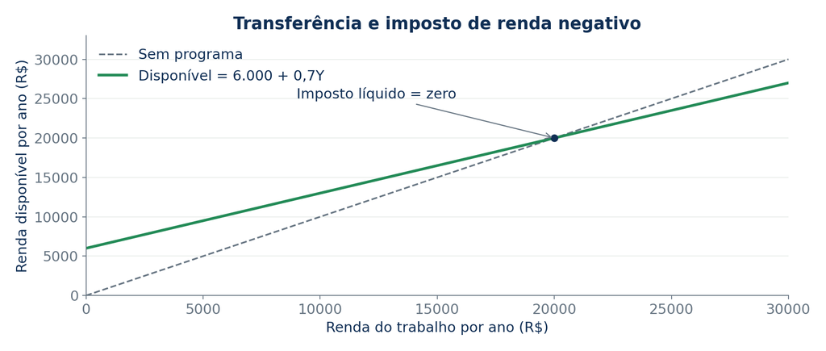

Renda disponível cresce com renda do trabalho no exemplo de imposto negativo, preservando 70 centavos de cada real adicional.

Fonte: elaboração didática. Dados hipotéticos, salvo indicação expressa.

Nesse exemplo, ganhar R$ 1 a mais aumenta a renda disponível em R$ 0,70. A retirada parcial do benefício reduz o ganho marginal, mas não o zera.

O desenho combina um piso de proteção e uma taxa de retirada. Alterar um desses parâmetros afeta cobertura e custo fiscal.

← Menu

## 23 - Dinheiro ou provisão de serviços?

Transferir dinheiro amplia a autonomia da família para escolher conforme suas necessidades. Oferecer bens e serviços diretamente pode garantir acesso a itens essenciais e enfrentar falhas de oferta.

| Aspecto | Pergunta de avaliação |
| --- | --- |
| Autonomia | A família pode adaptar o uso do recurso? |
| Oferta | Existem serviços acessíveis e de qualidade? |
| Externalidades | Há efeitos sobre saúde, educação e outras pessoas? |
| Implementação | Quais custos, barreiras e riscos de exclusão existem? |

Não há superioridade automática de um instrumento em todas as situações. Políticas podem combinar renda e serviços universais.

← Menu

## 24 - Incentivos e taxa marginal efetiva

Suponha que uma família receba exatamente a diferença entre sua renda e um piso. Se ganhar R$ 100 e perder R$ 100 de benefício, a renda disponível não aumenta.

A retirada equivale, nesse intervalo, a uma taxa marginal efetiva de 100%. Impostos e retirada de benefícios podem se acumular.

Transições graduais procuram preservar parte do ganho de trabalhar mais. Também é preciso observar transporte, cuidado de crianças e disponibilidade de emprego.

Identificar um incentivo não demonstra que todas as pessoas responderão da mesma forma, nem que a ausência de emprego seja uma escolha livre.

← Menu

## 25 - O desenho completo da política

Uma política deve ser avaliada por cobertura, suficiência do benefício, custo fiscal, acesso e efeitos sobre decisões e oportunidades.

Focalização pode concentrar recursos em quem mais precisa, mas critérios complexos podem excluir pessoas elegíveis. Universalidade simplifica acesso, mas exige mais recursos ou benefícios menores para um mesmo orçamento.

Há ainda a interação com educação, saúde, moradia e mercado de trabalho. Uma transferência isolada não remove todas as barreiras à autonomia.

O objetivo de reduzir pobreza pede atenção tanto à proteção imediata quanto às possibilidades futuras.

← Menu

## 26 - Jogo rápido: um desenho melhor?

Uma família recebe R$ 500. Ao conseguir R$ 100 de renda adicional, perde R$ 150 do benefício.

1. Quanto muda sua renda disponível?
2. Qual é a taxa de retirada do benefício nesse intervalo?
3. O que uma retirada de R$ 30 produziria no mesmo exemplo?

**Conferir respostas**

1. Cai R$ 50. 2. A retirada equivale a 150% do aumento de renda, antes de outros custos. 3. A família ganharia R$ 70 líquidos. O exemplo mostra a importância de evitar descontinuidades e de avaliar a combinação de programas.

← Menu

## 27 - Conclusão: medida, critério e política

Desigualdade e pobreza precisam ser medidas com conceitos claros. Renda anual, patrimônio, consumo, serviços e mobilidade revelam partes diferentes das condições de vida.

As políticas de redistribuição dependem também de critérios de justiça. Nenhum índice escolhe esses critérios por nós.

**Uma avaliação consistente combina proteção, oportunidades e efeitos econômicos.** Examina quem ganha, quem fica de fora, como a política é financiada e quais incentivos cria.

Nas próximas aulas, estudaremos como a demanda por fatores, a qualificação e a discriminação ajudam a explicar os rendimentos do trabalho.

← Menu

## Exercícios de concursos públicos

Oito exercícios selecionados. Nos itens de julgamento, use **C (certo/verdadeiro)** ou **E (errado/falso)**. Leia os enunciados antes de abrir as respostas. As fontes e as adaptações estão identificadas em cada questão.

### Questão 01

CESPE, Câmara dos Deputados, Analista Legislativo / Assistente Técnico, FC de Consultor Legislativo, Área V, 2002 · questão 75, 2º item

Os modernos modelos de crescimento endógeno estabelecem um impacto positivo da concentração de renda sobre o potencial de crescimento. Concentrando-se a renda, elevar- se-á a poupança, o que viabilizará um maior investimento e aumentará o crescimento potencial.

**( ) C ( ) E**

Item original C/E, com normalização de espaçamento. A prova autoriza reprodução com indicação da fonte.

[Prova original](https://cdn.cebraspe.org.br/concursos/_antigos/2003/camaradosdeputados/ARQUIVOS/area_05.pdf) · [Gabarito oficial](https://cdn.cebraspe.org.br/concursos/_antigos/2003/CAMARADOSDEPUTADOS/Arquivos/Gab_Def_CD.pdf)

Resposta comentada

### Questão 02

CESPE, Câmara dos Deputados, Analista Legislativo / Assistente Técnico, FC de Consultor Legislativo, Área V, 2002 · questão 75, 3º item

As políticas sociais do tipo bolsa-escola (benefício monetário a uma população específica que tem como contrapartida a escolarização das crianças) podem ser fundamentadas na teoria do capital humano e no círculo vicioso da pobreza.

**( ) C ( ) E**

Item original C/E, com normalização de espaçamento. A prova autoriza reprodução com indicação da fonte.

[Prova original](https://cdn.cebraspe.org.br/concursos/_antigos/2003/camaradosdeputados/ARQUIVOS/area_05.pdf) · [Gabarito oficial](https://cdn.cebraspe.org.br/concursos/_antigos/2003/CAMARADOSDEPUTADOS/Arquivos/Gab_Def_CD.pdf)

Resposta comentada

### Questão 03

CESPE, Câmara dos Deputados, Analista Legislativo / Assistente Técnico, FC de Consultor Legislativo, Área V, 2002 · questão 75, 4º item

A teoria da justiça como equidade discutida no item está associada a qual autor?

1. Robert Nozick
2. Jeremy Bentham
3. John Rawls
4. Thomas Malthus
5. Adam Smith

Adaptação didática de um item C/E para múltipla escolha; alternativas criadas para a aula. O item original sobre Rawls tem gabarito C.

[Prova original](https://cdn.cebraspe.org.br/concursos/_antigos/2003/camaradosdeputados/ARQUIVOS/area_05.pdf) · [Gabarito oficial](https://cdn.cebraspe.org.br/concursos/_antigos/2003/CAMARADOSDEPUTADOS/Arquivos/Gab_Def_CD.pdf)

Resposta comentada

### Questão 04

CESPE, Câmara dos Deputados, Analista Legislativo / Assistente Técnico, FC de Consultor Legislativo, Área V, 2002 · questão 75, 5º item

As políticas de renda mínima têm adeptos tanto no liberalismo econômico (por exemplo, Milton Friedman) quanto na esquerda (como André Gorz).

**( ) C ( ) E**

Item original C/E, com normalização de espaçamento. A prova autoriza reprodução com indicação da fonte.

[Prova original](https://cdn.cebraspe.org.br/concursos/_antigos/2003/camaradosdeputados/ARQUIVOS/area_05.pdf) · [Gabarito oficial](https://cdn.cebraspe.org.br/concursos/_antigos/2003/CAMARADOSDEPUTADOS/Arquivos/Gab_Def_CD.pdf)

Resposta comentada

### Questão 05

Cebraspe, TCE/SC, Auditor Fiscal de Controle Externo, Economia, 2016 · questão 86

Quanto mais o Gini se aproxima de 1, menor é a concentração da renda.

**( ) C ( ) E**

Recorte conceitual do item 86; mantido o sentido incorreto da afirmação sobre o Gini. Gabarito original: E.

[Prova original](https://cdn.cebraspe.org.br/concursos/TCE_SC_15/arquivos/230TCESC_004_01.pdf) · [Gabarito oficial](https://cdn.cebraspe.org.br/concursos/TCE_SC_15/arquivos/Gab_Definitivo_230TCESC_004_01.pdf)

Resposta comentada

### Questão 06

CESPE, Senado Federal, Consultor Legislativo, Área 14, 2002 · questão 56, 2º item

De acordo com a hipótese do ciclo de vida, o consumo depende tanto da renda quanto da riqueza dos consumidores e implica, também, que a poupança varie, ao longo da vida, de maneira previsível.

**( ) C ( ) E**

Item original C/E, com normalização de espaçamento. A prova autoriza reprodução com indicação da fonte.

[Prova original](https://cdn.cebraspe.org.br/concursos/_antigos/2002/senado/Arquivos/area_14_LEGISL_1Et.pdf) · [Gabarito oficial](https://cdn.cebraspe.org.br/concursos/_antigos/2002/senado/Arquivos/Gab_Def-SENADO.pdf)

Resposta comentada

### Questão 07

CESPE, Senado Federal, Consultor Legislativo, Área 14, 2002 · questão 70, 1º item

De maneira geral, há consenso de que, para os países em desenvolvimento, um aumento de salário mínimo tem impacto positivo sobre os demais salários da economia, reduzindo o desemprego e os níveis de pobreza.

**( ) C ( ) E**

Item original C/E, com normalização de espaçamento. A prova autoriza reprodução com indicação da fonte.

[Prova original](https://cdn.cebraspe.org.br/concursos/_antigos/2002/senado/Arquivos/area_14_LEGISL_1Et.pdf) · [Gabarito oficial](https://cdn.cebraspe.org.br/concursos/_antigos/2002/senado/Arquivos/Gab_Def-SENADO.pdf)

Resposta comentada

### Questão 08

CESPE, Senado Federal, Consultor Legislativo, Área 14, 2002 · questão 73, 4º item

Há evidências empíricas demonstrando que o emprego feminino tende a ser concentrado em determinados setores da economia e agrupado em um conjunto limitado de profissões, sendo essa segmentação um dos pilares das desigualdades entre homens e mulheres no mercado de trabalho.

**( ) C ( ) E**

Item original C/E, com normalização de espaçamento. A prova autoriza reprodução com indicação da fonte.

[Prova original](https://cdn.cebraspe.org.br/concursos/_antigos/2002/senado/Arquivos/area_14_LEGISL_1Et.pdf) · [Gabarito oficial](https://cdn.cebraspe.org.br/concursos/_antigos/2002/senado/Arquivos/Gab_Def-SENADO.pdf)

Resposta comentada

**Gabarito resumido e resoluções comentadas**

| Questão | 01 | 02 | 03 | 04 | 05 | 06 | 07 | 08 |
| --- | --- | --- | --- | --- | --- | --- | --- | --- |
| Resposta | E | C | C | C | E | C | E | C |

**Questão 01: E**

Uma elevação da concentração não assegura crescimento maior. Educação, saúde, financiamento e inclusão produtiva também afetam a capacidade de produzir. Deve-se analisar os mecanismos, em vez de transformar uma hipótese sobre poupança em lei universal.

Voltar ao enunciado

**Questão 02: C**

O programa pode atuar sobre a renda presente e sobre a formação das crianças, enfrentando transmissão intergeracional da pobreza. A avaliação precisa considerar focalização, qualidade escolar e efeitos de incentivo.

Voltar ao enunciado

**Questão 03: C**

John Rawls propõe avaliar princípios de justiça sem conhecer a posição que se ocupará na sociedade. No critério apresentado no capítulo, o foco recai sobre as condições dos menos favorecidos. A teoria difere do utilitarismo e da defesa libertária dos direitos de propriedade.

Voltar ao enunciado

**Questão 04: C**

Apoio à renda mínima pode resultar de justificativas diferentes: autonomia e simplificação do sistema, de um lado, ou proteção social e emancipação, de outro. Compartilhar um instrumento não implica compartilhar toda a concepção de justiça.

Voltar ao enunciado

**Questão 05: E**

Na escala convencional entre 0 e 1, zero corresponde à igualdade perfeita e valores mais elevados indicam maior desigualdade. Este é um dos erros do item original; a síntese retém apenas esse ponto.

Voltar ao enunciado

**Questão 06: C**

Desigualdade medida em um único ano mistura diferenças persistentes com etapas da vida e oscilações temporárias. Isso não elimina desigualdades de oportunidade; exige escolher com cuidado período e unidade de análise.

Voltar ao enunciado

**Questão 07: E**

Não há consenso universal de que qualquer elevação do piso salarial reduza simultaneamente desemprego e pobreza. Importam o piso inicial, a estrutura do mercado, a fiscalização, a demanda de trabalho e quem vive nos domicílios pobres.

Voltar ao enunciado

**Questão 08: C**

Segregação ocupacional pode limitar acesso a profissões e trajetórias de remuneração. A diferença observada exige investigar oportunidades, discriminação, jornada, cuidado e características dos postos, sem atribuir tudo a uma única causa.

Voltar ao enunciado

← Menu